# Introducción a la regresión y correlación

21/4/2021

## Diferencias con experimentos factoriales

1. ANOVA - Variables independientes son categóricas, valores no indican magnitud:

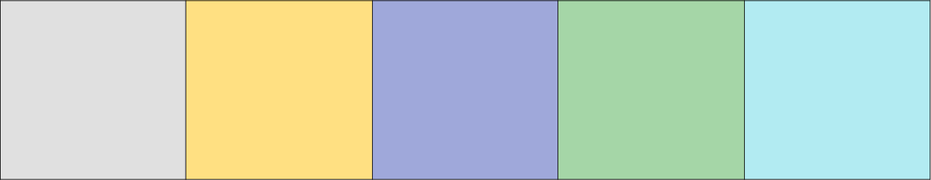

Variables categóricas.

```
  1.1. Compuestos fertilizantes, tipos de suelo, especies de organismos
```

## Diferencias con experimentos factoriales

1. Regresión y correlación - Variables independientes contínuas, valores indican magnitud:

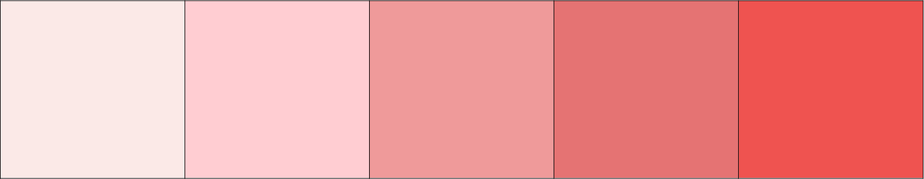

Variables contínuas

```
  1.1. Temperatura, concentración de un fertilizante, frecuencia de riego
```

## Diferencias con experimentos factoriales

1. Hipótesis

   1.1. ANOVA - efecto de tratamientos sobre **valor medio en grupo experimental** (un parámetro por nivel o tratamiento)

   ```
        - Diferencias entre tratamientos
   ```

   1.2. Regresión - efecto de variable sobre **cambio del valor medio** en relación a variable independiente

   ```
        - Magnitud y fuerza del efecto
   ```

## Diferencias y similitudes entre Corr y Reg

1. Ambas describen asociaciones entre variables

   1.1. Pueden medir *fuerza* de asociación
2. Regresión mide el cambio cuantitativo entre una y otra

   2.1. Asume relación causa-efecto
3. Correlación no mide cambio

   3.1. No asume causa-efecto

## Causa-efecto

1. Correlación de \(x\) con \(y\) = Correlación de \(y\) con \(x\)
2. Regresión de \(x\) con \(y \neq\) Correlación de \(y\) con \(x\)

   2.1. Regresión asume que \(y(x) = a + b x\)

   2.2. \(y\) es producida por \(x\)

   2.3. \(a\) y \(b\) ajustan unidades y tasa de cambio
3. ¡**REGRESIÓN SE USA PARA ESTIMAR** \(a\) y \(b\)!

## Relaciones lineales

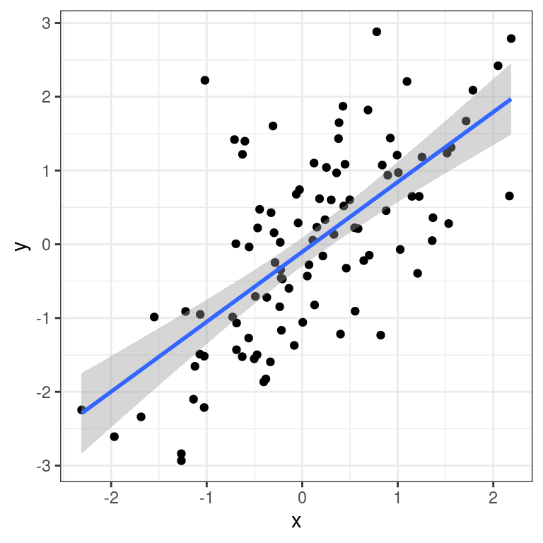

Relación lineal entre dos variables aleatorias \(x, y\).

## Fuerza de asociación

1. Correlación \(\rightarrow\) estimar coeficiente de correlación \(r\) (varianza de una explicada por la otra):

   1.1. Decribe tanto *fuerza* como *dirección*
2. Regresión \(\rightarrow\) estimar coeficiente de determinación \(r^2\)

   2.1. Decribe *fuerza*, la dirección es medida por \(b\)

## Ejemplos

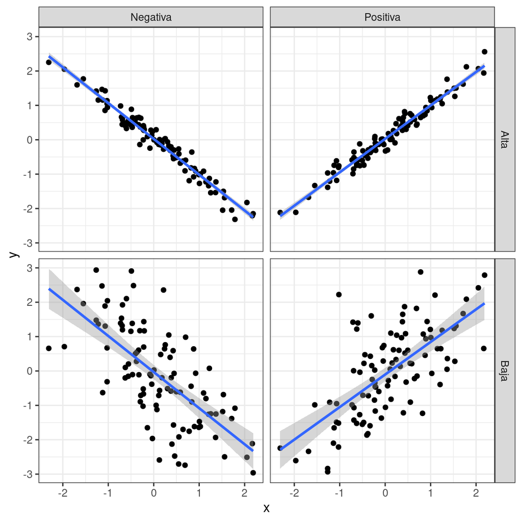

## Interpretación de coeficientes

1. Correlación

   1.1. \(1 \geq r \leq -1\)

   1.2. \(r > 0\), \(y\) aumenta si \(x\) aumenta

   1.3. \(r < 0\), \(y\) disminuye si \(x\) aumenta

   1.4. \(r = 0\), \(y\) no cambia con \(x\)

   1.5. \(r = \{1, -1\}\), \(y\) forma línea recta perfecta con \(x\)

## Interpretación de coeficientes

1. Regresión

   1.1. \(0 \geq r^2 \leq 1\)

   1.2. \(r = 0\), \(y\) no cambia con \(x\)

   1.3. \(r = 1\), \(y\) forma línea recta perfecta con \(x\)

   1.4. \(-\infty \geq \{ a, b \} \leq \infty\)

   1.5. \(b > 0\), \(y\) aumenta si \(x\) aumenta

   1.7. \(b < 0\), \(y\) disminuye si \(x\) aumenta

## Ejemplos gráficos

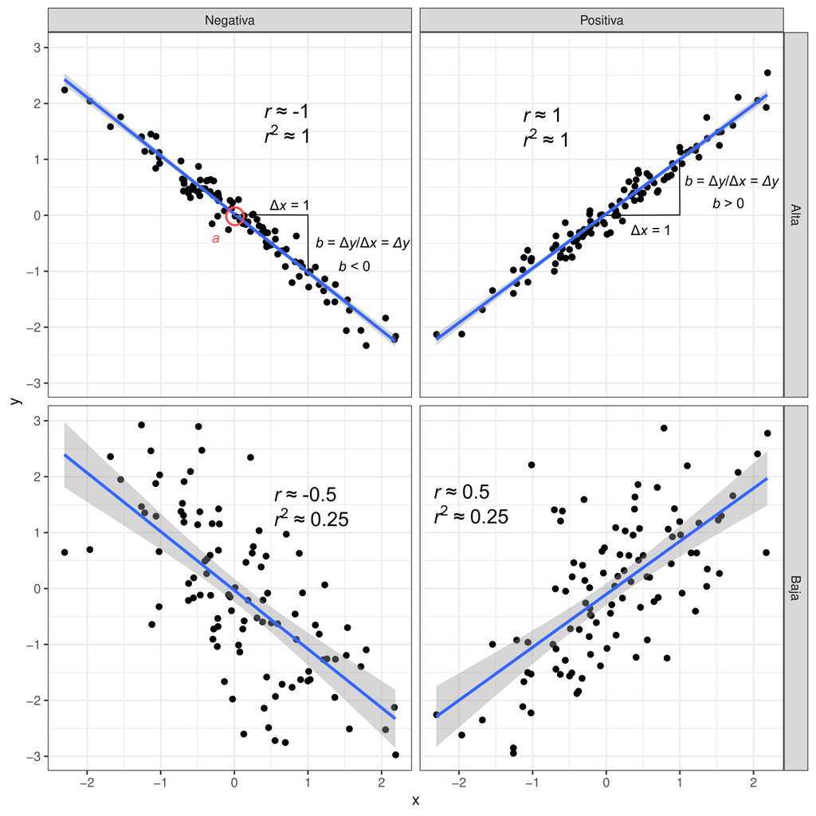

Coeficientes de regresión y correlación.

## Fin

Regresar al índice del curso